# 7 Hajontalukuja, jakauman kuvailua, muuttujamuunnoksia ja hypoteesintestausta

## 7.1 Varianssi ja keskihajonta

[figure not shown]

Varianssi on keskihajonta korotettuna toiseen. Salmela (2026)

Keskihajonnassa lasketaan jokaisen havaintopisteen ero keskiarvosta korotettuna toiseen yhteen, jaetaan summa n:llä ja otetaan siitä neliöjuuri. Otoskeskihajonnassa jaetaan n-1:llä.

Tilastollinen testaus perustuu suurelta osin hajontaan

- esim t-testi, eroaako keskiarvo nollasta?

[figure not shown]

## 7.2 Jakauman muoto

### 7.2.1 Vinous / skewness

- jos 0, niin täysin symmetrinen
- Negative skew
  - enemmän pieniä arvoja –> häntä pieniin arvoihin
- Positive skew
  - Enemmän suuria arvoja -> Häntä suuriin arvoihin

### 7.2.2 Huipukkuus / kurtosis

- Piikikäs (leptokurtic), positive kurtosis
- Normaalijakauma (mesokurtic)
- Tasainen / flat /platykurtic), negative kurtosis

Normaalijakaumaa piikikkäämpi on siis kurtoosiltaan positiivinen ja normaalijakaumaa tasaisempi on kurtoosiltaan negatiivinen.

#### 7.2.2.1 Jakauma ja tiheysfunktio

- Tiheys = frekvenssi jaettuna palkin leveydellä

### 7.2.3 Noudattaako jakauma normaalijakaumaa?

#### 7.2.3.1 Tehdään tilastotesti

- Shapiro-wilk test
- Kolmogorov-Smirnov testi
- Jos tilastotesti merkitsevä, p < 0,05, niin jakauma poikkeaa normaalijakaumasta
- Jamovi -> moretests moduuli

Shapiro-wilk ja Kolmogorov-Smirnov testien toimivuus riippuu aineiston koosta, voivat olla liian liberaaleja/konservatiivisia

- shapiro-wilk parempi pienellä aineistolla
- Kolmogorov-Smirnov parempi isolla

#### 7.2.3.2 Verrataan jakauman muotoa normaalijakaumaan —> Piirrä Q-Q-Plot

- verrataan jakaumaa teoreettiseen jakaumaan tai kahta jakaumaa keskenään
- jos jakaumat samanlaisia kaikki pisteet osuvat suoralle viivalle

[figure not shown]

jos pisteet osuvat vinolle viivalle kuten kuvassa -> jakauma on normaalijakautunut

### 7.2.4 Box plot & violin plot

- box plot
  - mediaani, 25-75 persentiiliväli (IQR, Inter quartal range), 25 – 1,5* IQR, 75 + 25 * IQR
- Violin plot
  - näyttää miten muuttujan jakauma on jakautunut alueelle

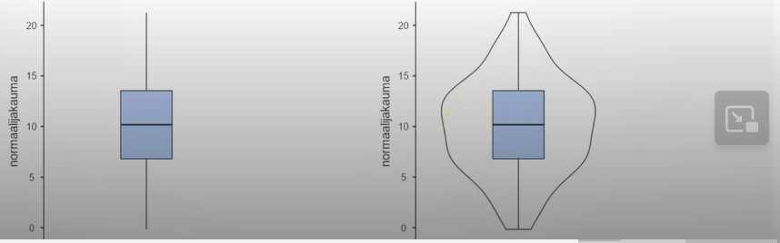

### 7.2.5 Outlier / poikkeava havainto

- usein tärkeää löytää, poistaa tai ottaa huomioon outlierit eli poikkeavat havainnot
- joskus datan syöttövirheitä, tärkeää tarkistaa alkuperäisestä aineistosta!
- Aina ei ole syytä poistaa poikkeavia havaintoja
- myöhemmin käsitellään tarkemmin millä kriteereillä outliereita voi poistaa

## 7.3 01.11 Histogrammin piirtäminen r-kielellä:

[figure not shown]

binwidth = palkin leveys

fill = palkin täyttöväri

alpha = läpinäkyvyysaste

colour = reunojen väri

labs = labels eli otsikot

## 7.4 05.11 Aineiston esikäsittely, valikointi ja poikkeavat havainnot

Muuttujien laskut ja muunnokset Jamovissa

- Compute variables
  - summa-muuttuja, keskiarvo-muuttuja, syntymävuosi iäksi, filter, jne.
- Transform variables
  - uudelleekoodaus, luokittele aineisto kolmeen ikäluokkaan, muuta jatkuva muuttuja kategoriseksi
  - saman transformaation voi soveltaa moneen muuttujaan
  - loogiset operaatiot
- Filters
  - filters toiminnolla voidaan poistaa yksittäisen tutkittavan kaikki vastaukset
  - filters toiminnon sijaan on usein parempi uudelleenkoodata muuttuja (COMPUTE / TRANSFORM) tai merkitä yksittäiset arvot poikkeaviksi

### 7.4.1 AINEISTON VALIKOINTI

- yksittäisiä arvoja poistettaessa Jamovissa missing values toiminto hyvä
- jos haluaa filtteröidä enemmän kuin vain yksittäisiä arvoja filtteröinti toiminto parempi

18 – Poikkeavat havainnot

- Poikkeavia havaintoja (outliers) voidaan tarkastella sen jälkeen, kun selkeästi virheelliset arvot ovat poistettu
- voi tarkastella visuaalisesti histogrammista tai Q-Q-plotista
- voi myös laskea erilaisia kriteerejä
  - Box-plotista IQR kriteerillä
  - Z-pisteet
    - standardointi, x-hajonnan päässä
  - mean +/- x *stdev
  - stdev = standard deviation
  - medidan +/- x*mad
  - mad = median absolute deviation
    - MAD suositeltavin menetelmä kaikista
- Poistettavia arvoja voi olla aivan korkeintaan muutamia prosentteja aineistosta
- Jos aineistosta poistaa poikkeavia havaintoja taustamuuttujien mukaan kannattaa verrata ryhmäeroja ja onko jäjelle jäänyt otos hyvä vai biasoitunut jotenkin

### 7.4.2 MAD-arvon laskenta

Median absolute deviation

- Rj editorissa: mad(data$MeanRT)
- mad funktiolla lasketaan mad arvo. data ja $ viittaavat tiettyyn dataframeen, josta se lasketaan esim. MeanRT.
- katsotaan muuttujan mediaani -> katsotaan kuinka paljon arvot poikkeavat mediaanista -> mad on niiden poikkeamien mediaani, kun poikkeamista on otettu itseisarvo
  - eli mikä on absoluuttisten poikkeamien mediaani koko jakauman mediaanista

Tietystä dataframen sarakkeesta hakeminen

- median(data$MeanRT)
- dollarimerkki -> saadaan haettua tietystä sarakkeesta data. Esim yllä olevassa MeanRT:stä.

Muuttujan tuloksen tallentaminen toiseen muuttujaan

- medianVal = median(data$MeanRT)
- madVal = mad(data$MeanRT)
- **medianVal = …**: tallentaa tuloksen muuttujaan medianVal.
- = merkillä voi siis tallentaa jonkin tuloksen tms, jotta sitä on helpompi käyttää myöhemmin
- voi käyttää myös <- merkkiä eli tähän malliin variable <- 150 ; talletettiin 150 variable muuttujaan

Laske MAD x 3 rajat outlierien poissulkuun

- medianVal - 3*madVal
- medianVal + 3*madVal

### 7.4.3 Transformaation teko Jamovissa

- klikkaa valitusta muuttujasta oikella hiirellä -> luo transformed variable -> valitse source variable -> luo transfomaatio

ei haluttujen arvojen filtteröinti transformaatiolla

- if else lausekkeilla
  - if < alaraja
  - if > yläraja
  - else $ source

MAD kriteerin sijaan voi käyttää myös keskiarvoa tai keskihajontaa

- keskiarvo r kielellä: mean
- keskihajonta: sd
- meanVal = mean(data$MeanRT)
- sdVal = sd(data$MeanRT)
  - meanVal - 3*sdVal
  - meanVal + 3*sdVal

Jos merkataan puuttuva arvo jamovissa niin r-kielellä täytyy lisätä lauseke:

- na.rm = TRUE
- tarkoittaa, että jos löytyy puuttuva arvo niin se jätetään huomiotta
- muuten näkyy vain NA

Jos aineistossa on selkeitä ääriarvoja niin mediaaniin perustuva outlier kriteeri järkevämpi

- koska ääriarvo vaikuttaa keskiarvoon merkittävästi, kun mediaaniin taas vähemmän

Transformaatiota voidaan käyttää toisissa muuttujissa ja se toimii samalla tavalla siinäkin

## 7.5 Summamuuttujat

- yhdistelmä useita muuttujia
- esim. kysely, jossa 10 kysymystä mittaa yhtä ominaisuutta
  - muodestetaan niistä summamuuttuja
- pitää ottaa huomioon kysymysten mahdollinen käänteinen koodaus
- Koodikirja (codebook)
  - jokaisen aineiston yhteydessä tulisi olla tarkemmat tiedot miten muuttujat on määritelty, käsitelty ym.
  - esim. mitä tarkoittaa sukupuoli 1,2, onko 1 mies vai nainen
  - esim. mitkä kysymykset on käänteisesti koodattu

Jamovissa

- insert computed variable
- summataan muuttujat yhteen
- kun jotkin muuttujista ovat käänteisessä järjestyksessä koodattuja
- esim. kyselytutkimuksessa kyselyasteikko 1-5, mutta jossain kysymyksissä asteikko päinvastoin
- kun vähennetään käänteisellä asteikolla saatujen vastaukset 6:ta saadaan ne käännettyä oikein päin
  - esim. käänteisellä asteikolla 4 -> 6 – 4 = 2
  - tai 5 ->6-5 = 1
  - 3 -> 6-3 = 3
  - 2 -> 6-2 = 4
  - 1 -> 6-1 = 5

## 7.6 Muuttujan standardointi

Muuttujan standardointi

- z-pistemuunnos, normalisointi, standardointi
- kaikki tarkoittavat samaa asiaa
- tarkoittaa sitä, että muuttujan arvot skaalataan niin, että sen keskiarvo on nolla ja keskihajonta yksi

Laskemalla

- vähennä muuttujan kys. arvosta kaikkien arvojen keskiarvo ja jaa tulos keskihajonnalla

[figure not shown]

scale() funktiolla

- standardoitun muuttujan keskiarvo on 0 ja keskihajonta 1
- Erityyppisiä muuttujia pystytään vertailemaan keskenään
- z-pistejakauma = standardi normaalijakauma
  - mean = 0, stdev = 1

Jamovissa:

- scale funktiolla tai
- = Sinnikkyys-VMEAN(Sinnikkyys) -> tällä saadaan keskiarvo nollaan
- VMEAN yms. V-funktiot jamovissa tarkoittavat muuttujan arvoa
  - eli lausekkeessa Sinnikkyyden jokaisesta arvosta vähennetään koko muuttujan keskiarvo. Eli vähennettävä arvo ei vaihtele koehenkilö/arvokohtaisesti vaan kaikilta vähennetään sama arvo
  - lausekkeeseen lisättiin vielä jako VSTDEV, eli keskihajonnalla jakaminen
  - tällöin saadaan vastauksena standardoidut arvot

Kysyin copilotilta miten MEAN ja VMEAN funktiot eroavat Jamovissa:

[figure not shown]

Eli, jos ymmärsin oikein MEAN funktiolla lasketaan kyseisen rivin kaikkien arvojen keskiarvo ja VMEAN funktiolla sarakkeen kaikkien arvojen keskiarvo.

## 7.7 Jakauman muutokset

Monet tilastotestit vaativat/olettavat, että jakauma on normaalisti jakautunut

- jos on normaalisti jakautunut voi tehdä melkein minkä vain tilastotestin
- Parametriset tilastotestit olettavat normaalisti jakautuneen muuttuja

Vino jakauma voidaan muuntaa muunnoksella enemmän normaalijakautuneeksi

- voidaan yrittää korjata muuttujamuunnoksella
- LOG, SQRT, BOXCOX, jne.
- kokeile eri muunnoksia, vertaile histogrammia, tee normaaliustesti
- Jos ei onnistu niin tee ei-parametrinen tilastotesti
- ei tee oletuksia muuttujien jakaumasta: jakauma-vapaa testi

Usein tilastotestit sietävät jonkin verran normaalijakaumasta poikkeamista

- usein tärkeämpää, että tilastollisen testin/mallin residuaali eli jäännösvirhe on normaalisti jakautunut

LOG = logaritmimuunnos

SQRT = neliöjuurimuunnos

Jamovissa BoxCox muunnos

- computed variable –>
- =BOXCOX(`MeanRT - FilterOutliers`, 0)
- 0 on lambda kerroin?

[figure not shown]

Pelkän visuaalisen tarkastelun lisäksi voidaan tehdä normaalisuustesti

- Shapiro-wilk suoraan jamovissa
  - toimii pienellä aineistolla hyvin, mutta isolla ei
- Isolla aineistolla Kolmogorov-Smirnov on parempi

### 7.7.1 BoxCox muunnos R-kielellä

- ks.test(scale(data$`MeanRT - FilterOutliers`), “pnorm”)
- scale tarkoitti standardointia, data$ viittaa dataan, josta testi tehdään ja ”pnorm” tarkoittaa, että verrataan normaalijakaumaan

[figure not shown]

- p-arvohyvin pieni 2e-07 = 2×10(potenssiin −7) = 0.0000002
- p arvo merkittävästi alle 0,05, joten se on tilastollisesti merkitsevä eli testin mukaan jakauma ei ole normaalisti jakautunut

[figure not shown]

- yllä olevan testin prompti: ks.test(scale(data$`BoxCox(RT)`), “pnorm”)
- data vaihdettiin BoxCox muunnoksen läpikäyneeseen muuttujaan
- sen myötä jakauma oli lähempänä normaalisesti jakautunutta
- p-arvo 0,3 on yli 0,05, joten se ei ole tilastollisesti merkitsevä -> tarkoittaa testissä että jakauma on normaalisti jakautunut

[figure not shown]

**Ensimmäisellä (alkuperäisellä) muuttujalla ei olisi voitu tehdä parametristä tilastotestiä, mutta toisella (BoxCox muunnoksen läpi käyneellä) muuttujalla voidaan, koska se on normaalijakautunut.**

Kun tehdään muunnoksia, mitta-asteikko muuttuu ja siksi se ei välttämättä ole järkevästi tulkittavissa. Tästä syystä kannattaa tehdä standardointi, jolloin se on tulkittavissa ja vertailtavissa. Silloin 0 = keskiarvo ja 1 askel tarkoittaa yhtä keskihajontaa.

## 7.8 Muuttujien uudelleenkoodaus

Uudelleenkoodauksen tyypillisiä tapauksia

- syntymävuoden muuttaminen iäksi
- jos aineistossa kerätty syntymävuosi, parempi muuttaa iäksi
- 4-luokkaisen muuttujan muuttaminen 2-luokkaiseksi
- jos ei tarpeeksi havaintoja jossain luokassa
- esim. yhdistää koulutus muuttujan luokkia
- Muuta jatkuva muuttuja kategoriseksi
  - esim. jos halutaan verrata ikäryhmiä niin ikä uudelleenkoodataan eri kategorioiksi
- Saman transformaation voi suoraan soveltaa useaan muuttujaan

[figure not shown]

Yllä transformaatio, jossa luokitellaan 4-luokkainen muuttuja 2-luokkaiseksi. Aiemmin luokat alle lukio (1), ylioppilas (2), maisteri (3), tohtori (4). ehtona, jos source on suurempi kuin 2 -> korkea koulutus, jos muu -> matala koulutus

- tällaisessa jaottelussa hyvä muistaa, että häiritsevänä muuttujana taustalla vaikuttaa ikä. Hyvin todnäk matalampi matalalla koulutustasolla ja korkeampi korkealla. -> täytyy ottaa tilastoanalyyseissa huomioon

Alla kuva iän jaottelusta luokkiin

- tehdään transformaatio -> määritellään luokat
  - videolla mm. määriteltiin persentiileistä ikäluokat seuraavalla tavalla
  - muuttujan mitta-asteikon saa vaihdettua edit transform kohdasta

[figure not shown]

## 7.9 Teoriaa, hypoteesintestaus

Tässä videossa

- todennäköisyysjakaumat
- hypoteesintestaus
- P-arvo
- Efektikoko
- Tilastollinen voima
- Luottamusväli

Jakaumat

- binomijakauma
  - Vaatii dikotomisen tapahtuman eli 2 vaihtoehtoa
  - binomijakauma on todennäköisyysjakauma, joka kertoo mahdollisten lopputulosten todennäköisyyden

[figure not shown]

- esim. kolikonheitto
  - toistetaan heitto n kertaa ja lasketaan kruunan lukumäärät
  - kuvassa sininen on n=20 ja p=0,5
  - tällöin on todennäköisintä, että saadaan kahdellakymmenellä heitolla 10 kruunaa
- vihreä n=20 p=0,7 (painotettu kolikko eli kruuna todennäköisempi)
  - todennäköisintä, että saadaan noin 14 kruunaa
- punainen n = 40 ja p = 0,5
  - todennäköisintä, että saadaan 20 kruunaa

Suurten lukujen laki – nopanheitto

- kuusi vaihtoehtoa, kaikki yhtä todnäköisiä
- monia kertoja toistettaessa keskiarvo kaikista heitoista lähestyy odotusarvoa
- eli esim. 20 heiton jälkeen keskiarvo saattaa olla vaikka 3 tai 4, mutta mitä suurempi määrä heittoja sitä lähemmäs asettuu odotusarvoa eli 3,5 (nopan silmälukujen keskiarvo)

[figure not shown]

suurten lukujen lain ansioista voidaan ennustaa asioita

- mikäli vain on tarpeeksi toistoja päästään odotusarvoon

### 7.9.1 Todennäköisyysjakaumia

Tilastotesteissä käytetyt

- Binomijakauma (esim. binomial testi)
- Normaalijakauma (esim. z-testi)
- T-jakauma (esim. t-testi)
- X<sup>2</sup> (chi-toiseen) -jakauma (esim. chi-square testit)
- F-jakauma (esim. ANOVA)

Muita

- Tasa-jakauma
  - sama todnäk saada kaikkia arvoja
- Beta-jakauma
- Gamma-jakauma
- Poisson-jakauma
- yms.

Perusjoukon ominaisuuksien estimointi otoksen avulla

- otoksessa ominaisuudella on havaittu jakauma
  - otostunnuslukuja: keskiarvo ja otoshajonta
    - nämä tiedetään!
- perusjoukossa ominaisuudella on teoreettinen jakauma
  - parametrejä: odotusarvo ja hajonta
    - nämä tuntemattomia!
- Voimme estimoida eli antaa arvioita parametreistä käyttämällä otostunnuslukuja ns. parametriestimaatteina
  - tätä pyritään tekemään tilastotesteillä
- matemaattinen malli teoreettisesta jakaumasta:
  - todennäköisyysjakauma: esim. normaalijakauma
- Todennäköisyys saada sellainen otos, jonka otoskeskiarvo on lähellä perusjoukon keskiarvoa, on suurempi kuin todennäköisyys saada otos, jonka otoskeskiarvo on kaukana perusjoukon odotusarvosta

[figure not shown]

Normaalijakauma

- 68-95-99,7 rule
  - yhden hajonnan väliin menee 68,27% arvoista
  - kahden hajonnan väliin 95,45 % arvoista
  - 3 hajonnan väliin 99,73% arvoista

### 7.9.2 Keskeinen raja-arvolause (central limit theorem for means)

- keskiarvo riittävän suuresta määrästä näytteitä/muuttujia noudattaa normaalijakaumaa, riippumatta muuttujien alkuperäisistä jakaumista
- jos poimitaan monta otosta samasta perusjoukosta, otoskeskiarvot noudattavat approksimatiivisesti normaalijakaumaa, jonka keskiarvo on perusjoukon odotusarvon kohdalla
- eli jos meillä on perusjoukko, oli tasa, vino, normaali tai mikä jakauma tahansa, niin kunhan poimitaan tarpeeksi otoksia ja lasketaan niistä otoskeskiarvo niin ne ovat normaalisti jakautunut ja keskiarvo perusjoukon keskiarvon kohdalla
  - Seuraus on se, että voidaan käyttää normaalijakaumaan perustuvia tilastotestejä ilman oletusta, että taustalla olevat jakaumat ovat normaaleja

Alkuperäinen jakauma eli perusjoukko voi siis olla mikä vaan

- perusjoukosta otetaan useita otoksia ja joka otoksesta lasketaan keskiarvo
- näiden otoskeskiarvojen jakauma jakautuu normaalisti
- otoskeskiarvojen keskiarvo asettuu myös perusjoukon keskiarvon kohdalle
- https://lipsanen.shinyapps.io/central_limit_theorem/

### 7.9.3 Tilastolliset johtopäätökset

- tilastotiede on oppia johtopäätösten teosta sellaisista ilmiöistä, joihin liittyy satunnaisuutta
- satunnainen = ei-deterministinen
  - Kaikkiin ihmisiin liittyviin ilmiöihin liittyy enemmän tai vähemmän satunnaisuutta
- tilastotestien johtopäätökset ovat muodoltaan todennäköisyysväittämiä
- todennäköisyys mittaa näiden väittämien varmuuden tai uskottavuuden astetta
- esim. ryhmien välinen ero on 1,5 yksikköä, onko tämä ero tilastollisesti merkitsevä?
- kuinka todennäköistä olisi löytää tällainen ero, jos sellainen on/ei ole perusjoukossa?
- 0 ≥ p ≤ 1

### 7.9.4 Hypoteesintestaus

nollahypoteesi ja vaihtoehtoinen hypoteesi

- tilastollinen testi: kumoutuuko nollahypoteesi H<sub>0</sub> vai jääkö se voimaan
- Esim. nollahypoteesi H<sub>0</sub>: ”ryhmien välillä ei ole eroa”, vaihtoehtoinen hypoteesi H<sub>1</sub>: ”ryhmien välillä on ero”
- Jos tilastollisen testin tulos on tilastollisesti merkitsevä H<sub>0</sub> hylätään ja H<sub>1</sub> tulee voimaan.
  - koska p<0,05 niin ryhmien välillä on tilastollisesti merkitsevä ero
- Jos tilastollisen testin tulos ei ole tilastollisesti merkitsevä, nollahypoteesi H<sub>0</sub> jää voimaan
- mutta sen tilastollisesta merkitsevyydestä ei voi sanoa mitään!
- Nollahypoteesi on voimassa, kunnes toisin osoitetaan

Shapiro-Wilk-testi

- nollahypoteesi H<sub>0</sub>: muuttuja on normaalisti jakautunut
- jos p<0,05 -> nollahypoteesi hylätään eli muuttuja ei ole normaalisti jakautunut
- jos p>0,05 -> nollahypoteesi jää voimaan eli muuttuja on normaalisti jakautunut
- tarkemmin: ei todista/osoita että muuttuja on normaalisti jakautunut vaan että ei ole evidenssiä hylätä oletusta muuttujan normaalijakautuneisuudesta
- jos iso aineisto niin kolmogorov-smirnov testi parempi

[figure not shown]

oletan, että shapiro-wilk testin kaava?

Esimerkki shapiro-wilk testin raportoinnista

[figure not shown]

### 7.9.5 Tilastollinen merkitsevyys, p-arvo

- 0,05 yleinen raja *
  - ei muuta perustetta kuin, että yleinen sopimus
- 0,01**, 0,001***
- arkoittaa, että löydetty ero on niin harvinainen, että sen täytyy olla todellinen
- riittävän monta kertaa toistettaessa, kuinka monta kertaa tulos olisi sattumalta merkitsevä
  - jos kriteeri on p<.05, niin 20 kertaa kokeen toistettaessa, 1 kerran saataisiin sattumalta merkitsevä tulos
- p-arvo määrittelee millä todennäköisyydellä virhe voidaan hyväksyä

[figure not shown]

Normaalijakauma ja p-arvo

### 7.9.6 Testisuureet

- Jokaisella tilastollisella testilla on testi-suure
- t-testillä t, ANOVAlla F, jne.
- Tiivistää tilastollisen testin tuloksen yhteen lukuun
- testisuuretta verrataan siihen, millainen se olisi, jos nollahypoteesi olisi voimassa
- kuinka yllättävä saamamme testisuure olisi, jos ero/yhteyttä/efektiä ei olisi oikeasti perusjoukossa
- Eri testisuureet noudattavat erilaisia jakaumia

### 7.9.7 Yksi- ja kaksisuuntaiset testit

- 2-suuntainen: Ryhmä 1 ≠ Ryhmä 2
  - otetaan todennäköisyysjakauman molemmista päistä 2,5%
  - käytetään, jos halutaan tietää vain että saako jompikumpi ryhmä suurempia arvoja
- 1-suuntainen, left-tailed: Ryhmä 1 < Ryhmä 2
- 1- suuntainen, right-tailed: Ryhmä 1 > Ryhmä 2
  - 1 suuntaisessa otetaan 5% jommastakummasta päästä
  - käytetään, jos halutaan tietää onko nimenomaan ryhmä 1 pienempi tai suurempi kuin ryhmä 2

[figure not shown]

Merkitsevä vs. merkittävä

- p-arvon pienuudesta tai suuruudesta ei voi päätellä mitään asian merkittävyydestä

### 7.9.8 Efektikoko

- arvio kuinka iso efekti/ero todellisuudessa on
  - cohenin d, eta squared
- Paljon merkitseviä tuloksia, osa sattumaa tai eivät erityisen kiinnostavia; jos efektikoko suuri, tulos kiinnostavampi
- Tilastollinen merkitsevyys = onko efekti ylipäänsä olemassa
- Efektin koko = minkä suuruinen efekti on (jos se on olemassa)

Cohenin d

- ryhmien välinen testi
- luku, joka vertaa keskiarvojen välistä eroa ryhmien sisäiseen hajontaan (pooled)
- eli muuntaa ryhmien välisen (abstraktin) eron keskihajonta yksiköille (vrt. standardoiminen)
- kuinka monen keskihajonnan päässä toisistaan ryhmät ovat
  - <.10 ei eroa
  - <.20 pieni ero
  - <.50 keskikokoinen ero
  - <.80 suuri ero
  - <1.10 todella suuri ero
  - <1.40 valtava ero

[figure not shown]

Cohenin d kaava?

### 7.9.9 Tilastollinen voima

- Tilastollinen voima kertoo, kuinka iso efekti ylipäätänsä on mahdollista löytää
- pitää tietää efektikoko (aiempien tutkimusten perusteella)
- voidaan arvioida kuinka iso otos pitää kerätä, että mahdollinen tilastollinen efekti voidaan löytää
- jos liian pieni otos, efektin löytämättömyys saattaa johtua tilastollisen voiman puutteesta

### 7.9.10 Keskiarvon luottamusväli

- keskiarvon keskivirhe (SEM)
- Luottamusväli kertoo keskiarvon luottamustason
- pystytään arvioimaan mittatuloksista millä todennäköisyydellä se on tietyllä välillä

[figure not shown]

Tilastollinen testaaminen

- mitä testiä aineistoon voi käyttää?
- Täyttyykö testien oletukset?
- Ovatko muuttujat yhteismitallisia?

Salmela, Viljami. 2026. *SPK-3003 R-Ohjelmointi 2026 [Luentosarja]*.